# Data Mining Project - Speed Dating Experiment Analysis

**Authors:** Tomasz Kisielewski, Robert Gosz, Antoni Kiciński  
**Dataset:** [Speed Dating Experiment](https://www.kaggle.com/datasets/annavictoria/speed-dating-experiment)

## 1. General Description of the Dataset

```python
import kagglehub

# Download latest version
path = kagglehub.dataset_download("annavictoria/speed-dating-experiment")

print("Path to dataset files:", path)
```

```
Path to dataset files: C:\Users\robert\.cache\kagglehub\datasets\annavictoria\speed-dating-experiment\versions\1
```

```python
import pandas as pd

df = pd.read_csv(f"{path}/Speed Dating Data.csv", encoding='latin1')
print(df.head())
print("\nShape of the dataset:")
print(df.shape)
```

```
   iid   id  gender  idg  condtn  wave  round  position  positin1  order  ...  \
0    1  1.0       0    1       1     1     10         7       NaN      4  ...
1    1  1.0       0    1       1     1     10         7       NaN      3  ...
2    1  1.0       0    1       1     1     10         7       NaN     10  ...
3    1  1.0       0    1       1     1     10         7       NaN      5  ...
4    1  1.0       0    1       1     1     10         7       NaN      7  ...

   attr3_3  sinc3_3  intel3_3  fun3_3  amb3_3  attr5_3  sinc5_3  intel5_3  \
0      5.0      7.0       7.0     7.0     7.0      NaN      NaN       NaN
1      5.0      7.0       7.0     7.0     7.0      NaN      NaN       NaN
2      5.0      7.0       7.0     7.0     7.0      NaN      NaN       NaN
3      5.0      7.0       7.0     7.0     7.0      NaN      NaN       NaN
4      5.0      7.0       7.0     7.0     7.0      NaN      NaN       NaN

   fun5_3  amb5_3
0     NaN     NaN
1     NaN     NaN
2     NaN     NaN
3     NaN     NaN
4     NaN     NaN

[5 rows x 195 columns]

Shape of the dataset:
(8378, 195)
```

The Speed Dating Experiment dataset was collected between 2002 and 2004 at Columbia University as part of a research study on partner preferences and romantic decision-making. The experiment consisted of 21 sessions (waves) of speed dating events, in which participants engaged in a series of 4-minute one-on-one conversations with potential partners. After each date, both participants independently indicated whether they would like to meet the other person again. A match occurred when both participants answered "yes."

The dataset covers much more than just the dating decisions. Before the event, participants were asked what they look for in a partner - they split 100 points across six traits: attractiveness, intelligence, sincerity, fun, ambition, and shared interests. They also rated themselves on those same traits. This makes it possible to compare what people say they want with how they actually make decisions. After each date, participants rated their partner on the same set of traits, gave an overall liking score, and estimated whether the partner would also say "yes." Basic personal information was also collected, such as age, field of study, career plans, and hobbies.

The dataset contains **8,378 records** representing individual speed dates, involving **551 unique participants** across **21 waves**. Each row corresponds to one speed date from the perspective of one participant. Since each date is recorded separately from both participants' perspectives, every date appears as two rows in the dataset.

## 2. Data Mining Goals and Success Criteria

### Primary Goal

**Classification:** Predict whether a speed date will result in a mutual match (`match = 1`), meaning both participants said "yes" to meeting again. The goal is not to predict long-term romantic success, but to understand what drives mutual attraction during a 4-minute speed date - specifically, which participant ratings, stated preferences, and personal characteristics make it more likely that both people will say "yes."

### Supporting Analytical Goals

The following exploratory analyses will support the primary classification goal and provide actionable insights:

1. **Baseline match rate** - Establish what proportion of speed dates result in a mutual match.
2. **Gender differences** - Determine whether men or women are more likely to say "yes" during speed dates.
3. **Feature importance for match** - Identify which attributes (attractiveness, fun, intelligence, sincerity, ambition, shared interests, overall liking, perceived reciprocity, and age) are most predictive of a match.
4. **Stated vs. revealed preferences** - Investigate whether participants' self-declared preferences (what they say they value in a partner) align with the attributes that actually predict their decisions.
5. **Self-assessment vs. outcomes** - Examine whether participants who rate themselves higher receive more matches.
6. **Pickiness effect** - Determine whether being more selective (saying "yes" to fewer people) leads to better or worse match outcomes.

### Success Criteria

- **Classification model:** The classification model should achieve at least 70% accuracy in predicting whether a speed date results in a mutual match.
- **Hidden patterns:** The exploratory analysis should uncover non-obvious relationships in the data - for example, whether being more selective actually increases your chances of a match, or whether what people say they want in a partner differs from what they actually respond to.
- **Golden client:** Based on the analysis, we aim to identify a profile of a participant most likely to result in a match - a combination of traits and behaviors (e.g. high fun rating, similar age, shared interests) that consistently predict mutual attraction.

## 3. Dataset Characteristics

```python
print("Dataset Characteristics:\n")
print(f"Number of records:       {len(df)}")
print(f"Number of attributes:    {len(df.columns)}")
print(f"Unique participants:      {df['iid'].nunique()}")
print(f"Number of waves:         {df['wave'].nunique()}")
match_rate = df['match'].sum() / len(df)
print(f"Match rate (positive):   {match_rate:.2%}")
print(f"No match rate (negative):{1 - match_rate:.2%}")
print(f"Total matches:           {df['match'].sum()}")
print("Match values:")
print(df['match'].value_counts())
```

```
Dataset Characteristics:

Number of records:       8378
Number of attributes:    195
Unique participants:      551
Number of waves:         21
Match rate (positive):   16.47%
No match rate (negative):83.53%
Total matches:           1380
Match values:
match
0    6998
1    1380
Name: count, dtype: int64
```

| Property | Value |
| --- | --- |
| Origin | Columbia University speed dating experiment (2002–2004) |
| Format | Single CSV file |
| Number of records | 8,378 |
| Number of attributes | 195 |
| Unique participants | 551 |
| Number of waves (sessions) | 21 |
| Level of observation | One row = one speed date from one participant's perspective |
| Target variable | `match` (binary: 0 or 1) |
| Class balance | ~16.5% positive (match), ~83.5% negative |

The dataset consists of a single flat file. Because each date is recorded twice (once per participant), pairs of rows share the same date but represent different viewpoints.

## 4. Description of Attributes

The types of variables were verified using pandas (df.dtypes), while their meaning was interpreted based on variable names and dataset description.

### Identifiers and context variables

- iid – unique participant identifier (numerical)
- gender – participant’s gender (categorical: 0 = female, 1 = male)
- wave – session number of the experiment (numerical)
- match – whether both participants agreed to meet again (binary: 0 = no, 1 = yes)

### Decision variables

- dec – participant’s decision after the date (binary: 0 = no, 1 = yes)
- dec_o – partner’s decision (binary: 0 = no, 1 = yes)

### Partner ratings (1–10 scale)

- attr – rating of partner’s attractiveness (numerical, scale 1–10)
- sinc – rating of partner’s sincerity (numerical, scale 1–10)
- intel – rating of partner’s intelligence (numerical, scale 1–10)
- fun – rating of partner’s fun (numerical, scale 1–10)
- amb – rating of partner’s ambition (numerical, scale 1–10)
- shar – rating of shared interests (numerical, scale 1–10)
- like – overall liking of the partner (numerical, scale 1–10)
- prob – probability of dating again (numerical, scale 1–10)

### Preferences (sum = 100%)

- attr1_1 – importance of attractiveness (numerical, percentage)
- sinc1_1 – importance of sincerity (numerical, percentage)
- intel1_1 – importance of intelligence (numerical, percentage)
- fun1_1 – importance of fun (numerical, percentage)
- amb1_1 – importance of ambition (numerical, percentage)
- shar1_1 – importance of shared interests (numerical, percentage)

### Self-evaluation (1–10 scale)

- attr3_1 – self-rated attractiveness (numerical, scale 1–10)
- sinc3_1 – self-rated sincerity (numerical, scale 1–10)
- intel3_1 – self-rated intelligence (numerical, scale 1–10)
- fun3_1 – self-rated fun (numerical, scale 1–10)
- amb3_1 – self-rated ambition (numerical, scale 1–10)

### Age variables

- age – participant’s age (numerical, years)
- age_o – partner’s age (numerical, years)

```python
# ==== SELECTED COLUMNS ====
cols = [
    "iid", "gender", "wave", "match",
    "dec", "dec_o",
    "attr", "sinc", "intel", "fun", "amb", "shar", "like", "prob",
    "attr1_1", "sinc1_1", "intel1_1", "fun1_1", "amb1_1", "shar1_1",
    "attr3_1", "sinc3_1", "intel3_1", "fun3_1", "amb3_1",
    "age", "age_o"
]

# ==== 1. TYPES ====
print("=== DATA TYPES ===")
print(df[cols].dtypes)

# ==== 2. RANGES (MIN / MAX) ====
print("\n=== RANGES (MIN / MAX) ===")
ranges = df[cols].agg(['min', 'max']).T
print(ranges)

# ==== 3. UNIQUE VALUES (BINARY / CATEGORICAL) ====
print("\n=== UNIQUE VALUES ===")
for col in ["gender", "dec", "dec_o", "match"]:
    print(f"{col}: {df[col].unique()}")

# ==== 4. CHECK RATING SCALE ====
print("\n=== RATING SCALE CHECK ===")
print(df[["attr", "sinc", "intel", "fun", "amb"]].agg(['min', 'max']))

# ==== 5. CHECK PREFERENCES SUM ====
print("\n=== PREFERENCES SUM (should be ~100) ===")
print(df[["attr1_1","sinc1_1","intel1_1","fun1_1","amb1_1","shar1_1"]].sum(axis=1).head())
```

```
=== DATA TYPES ===
iid           int64
gender        int64
wave          int64
match         int64
dec           int64
dec_o         int64
attr        float64
sinc        float64
intel       float64
fun         float64
amb         float64
shar        float64
like        float64
prob        float64
attr1_1     float64
sinc1_1     float64
intel1_1    float64
fun1_1      float64
amb1_1      float64
shar1_1     float64
attr3_1     float64
sinc3_1     float64
intel3_1    float64
fun3_1      float64
amb3_1      float64
age         float64
age_o       float64
dtype: object

=== RANGES (MIN / MAX) ===
           min    max
iid        1.0  552.0
gender     0.0    1.0
wave       1.0   21.0
match      0.0    1.0
dec        0.0    1.0
dec_o      0.0    1.0
attr       0.0   10.0
sinc       0.0   10.0
```

[output cut: 23 more lines]

```
dec_o: [0 1]
match: [0 1]

=== RATING SCALE CHECK ===
     attr  sinc  intel   fun   amb
min   0.0   0.0    0.0   0.0   0.0
max  10.0  10.0   10.0  10.0  10.0

=== PREFERENCES SUM (should be ~100) ===
0    100.0
1    100.0
2    100.0
3    100.0
4    100.0
dtype: float64
```

## 5. Explanatory Data Analysis

### 5.1 Distribution of Attribute Values

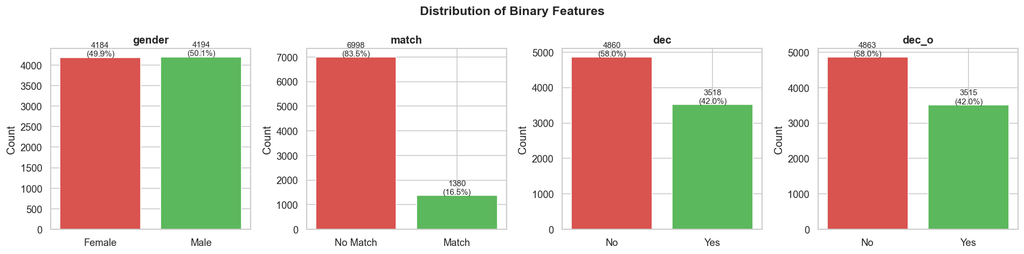

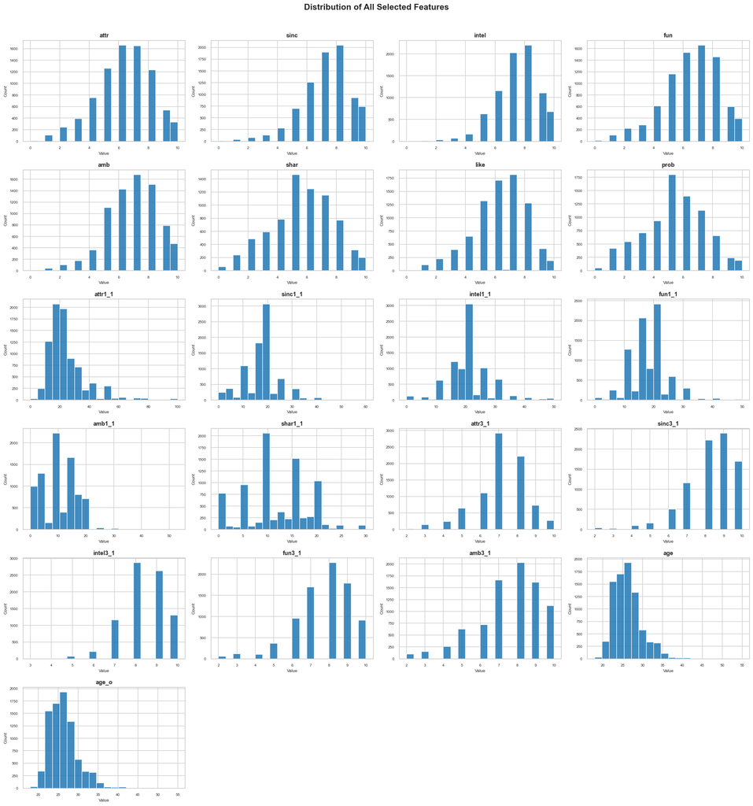

```python
import numpy as np
import matplotlib.pyplot as plt
import seaborn as sns
from scipy import stats


key_cols = [
    "gender", "match",
    "dec", "dec_o",
    "attr", "sinc", "intel", "fun", "amb", "shar", "like", "prob",
    "attr1_1", "sinc1_1", "intel1_1", "fun1_1", "amb1_1", "shar1_1",
    "attr3_1", "sinc3_1", "intel3_1", "fun3_1", "amb3_1",
    "age", "age_o"
]

binary_cols = ['gender', 'match', 'dec', 'dec_o']
binary_labels = {
    'gender': {0: 'Female', 1: 'Male'},
    'match':  {0: 'No Match', 1: 'Match'},
    'dec':    {0: 'No', 1: 'Yes'},
    'dec_o':  {0: 'No', 1: 'Yes'},
}

fig, axes = plt.subplots(1, 4, figsize=(16, 4))
for ax, col in zip(axes, binary_cols):
    counts = df[col].value_counts().sort_index()
    labels = [binary_labels[col][k] for k in counts.index]
    colors = ['#d9534f', '#5cb85c']
    bars = ax.bar(labels, counts.values, color=colors, edgecolor='white')
    ax.set_title(col, fontsize=12, fontweight='bold')
    ax.set_ylabel('Count')
    for bar, val in zip(bars, counts.values):
        ax.text(bar.get_x() + bar.get_width()/2, bar.get_height() + 30,
                f'{val}\n({val/len(df)*100:.1f}%)', ha='center', fontsize=9)
plt.suptitle('Distribution of Binary Features', fontsize=14, fontweight='bold')
plt.tight_layout()
plt.savefig('plot_distributions_binary.png', bbox_inches='tight')
plt.show()

continuous_cols = [c for c in key_cols if c not in binary_cols]
ncols = 4
nrows = int(np.ceil(len(continuous_cols) / ncols))

fig, axes = plt.subplots(nrows, ncols, figsize=(20, nrows * 3.5))
axes = axes.flatten()

for i, col in enumerate(continuous_cols):
    data = df[col].dropna()
    axes[i].hist(data, bins=20, color='#1f77b4', edgecolor='white', alpha=0.85)
    axes[i].set_title(col, fontsize=11, fontweight='bold')
    axes[i].set_xlabel('Value', fontsize=8)
    axes[i].set_ylabel('Count', fontsize=8)
    axes[i].tick_params(labelsize=7)

for j in range(len(continuous_cols), len(axes)):
    axes[j].set_visible(False)

plt.suptitle('Distribution of All Selected Features', fontsize=16, fontweight='bold', y=1.01)
plt.tight_layout()
plt.savefig('plot_distributions_grid.png', bbox_inches='tight')
plt.show()
```

```python
print("\n=== Shapiro-Wilk Normality Tests (sample n=500) ===")
print(f"{'Feature':<12} {'W statistic':>12} {'p-value':>10} {'Normal?':>8}")
print("-" * 46)

shapiro_results = []
for col in key_cols:
    data = df[col].dropna()
    sample = data.sample(min(500, len(data)), random_state=42)
    stat, p = stats.shapiro(sample)
    normal = "YES" if p > 0.05 else "NO"
    shapiro_results.append({'Feature': col, 'W': stat, 'p-value': p, 'Normal': normal})
    print(f"{col:<12} {stat:>12.4f} {p:>10.4f} {normal:>8}")

shapiro_df = pd.DataFrame(shapiro_results)
```

```
=== Shapiro-Wilk Normality Tests (sample n=500) ===
Feature       W statistic    p-value  Normal?
----------------------------------------------
gender             0.6363     0.0000       NO
match              0.4806     0.0000       NO
dec                0.6313     0.0000       NO
dec_o              0.6306     0.0000       NO
attr               0.9642     0.0000       NO
sinc               0.9405     0.0000       NO
intel              0.9389     0.0000       NO
fun                0.9575     0.0000       NO
amb                0.9511     0.0000       NO
shar               0.9725     0.0000       NO
like               0.9666     0.0000       NO
prob               0.9671     0.0000       NO
attr1_1            0.8038     0.0000       NO
sinc1_1            0.9516     0.0000       NO
intel1_1           0.8977     0.0000       NO
fun1_1             0.9299     0.0000       NO
amb1_1             0.9347     0.0000       NO
shar1_1            0.9544     0.0000       NO
attr3_1            0.9152     0.0000       NO
sinc3_1            0.8846     0.0000       NO
intel3_1           0.8985     0.0000       NO
fun3_1             0.9205     0.0000       NO
amb3_1             0.9323     0.0000       NO
age                0.9213     0.0000       NO
age_o              0.9415     0.0000       NO
```

The dataset is well-balanced in terms of gender (50.1% male, 49.9% female). The match rate is low at 16.5%. Both participants said "yes" (dec and dec_o) in approximately 42% of dates individually, confirming that matches are rare because both people must agree simultaneously.

**Partner ratings (attr, sinc, intel, fun, amb, shar, like, prob):** All ratings are measured on a 1–10 scale and show a left-skewed distribution which means scores tend to 6–9 range, with very few low ratings. This means participants generally rated their dates positively, which may reflect the social setting of the experiment where people are naturally more inclined to be generous in their evaluations. None of these variables follow a normal distribution (confirmed by Shapiro-Wilk tests, all p < 0.05).

**Stated preferences (attr1_1, sinc1_1, intel1_1, fun1_1, amb1_1, shar1_1):** These represent percentage allocations summing to 100. Attractiveness (attr1_1) shows the widest spread and a right-skewed distribution, with most participants allocating 15–30%. The remaining preference variables are more concentrated around their means, with occasional extreme values (e.g., someone allocating 60% to sincerity).

**Self-ratings (attr3_1, sinc3_1, intel3_1, fun3_1, amb3_1):** Participants rate themselves consistently high - distributions are left-skewed and concentrated in the 7–10 range, particularly for intelligence and sincerity. This is consistent with well-known self-enhancement bias in psychology.

**Age (age, age_o):** Both age distributions are right-skewed, with the majority of participants between 20 and 30 years old. A small number of participants are older (above 40), which may be considered outliers in the context of this dataset.

### 5.2 Correlations Between Attribute Values

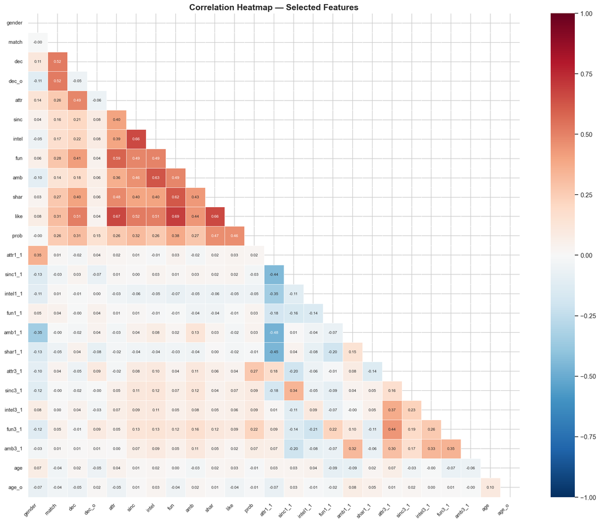

```python
corr_matrix = df[key_cols].corr()

fig, ax = plt.subplots(figsize=(16, 13))
mask = np.triu(np.ones_like(corr_matrix, dtype=bool))
sns.heatmap(
    corr_matrix,
    mask=mask,
    annot=True,
    fmt='.2f',
    cmap='RdBu_r',
    center=0,
    vmin=-1, vmax=1,
    ax=ax,
    annot_kws={'size': 7},
    linewidths=0.3
)
ax.set_title('Correlation Heatmap - Selected Features', fontsize=15, fontweight='bold')
plt.xticks(rotation=45, ha='right', fontsize=9)
plt.yticks(fontsize=9)
plt.tight_layout()
plt.savefig('plot_correlation_heatmap.png', bbox_inches='tight')
plt.show()
```

**Partner ratings are strongly correlated with each other:** the most noticeable pattern in the heatmap is the cluster of strong positive correlations among post-date partner ratings (`attr`, `sinc`, `intel`, `fun`, `amb`, `shar`, `like`). For example, `sinc` and `intel` correlate at **0.66**, `fun` and `like` at **0.69**, and `shar` and `like` at **0.66**. This suggests a **halo effect** - if a participant rates their date highly on one trait, they tend to rate them highly on others as well.

**Like and dec are the strongest predictors of match:** `like` (overall liking) shows the strongest correlation with both `dec` (0.51) and `match` (0.31). This is intuitive - if you genuinely like someone, you are more likely to say "yes" and more likely to get a mutual match. `fun` and `shar` also show moderate positive correlations with `match` (0.28 and 0.27 respectively).

**Stated preferences have almost no correlation with actual ratings:** the preference variables (`attr1_1`, `sinc1_1`, `intel1_1`, etc.) show near-zero correlations with the actual post-date ratings and with `match`. This is a key finding - **what people say they value before the event has very little to do with how they actually rate their dates**. The only notable exception is `attr1_1` which correlates with `gender` (0.35), suggesting men place more importance on attractiveness than women.

**Preference variables are negatively correlated with each other:** since preferences must sum to 100%, allocating more points to one trait means less for others. This explains the negative correlations between preference variables - for example, `attr1_1` and `amb1_1` correlate at **-0.48**, and `attr1_1` and `sinc1_1` at **-0.44**.

**Self-ratings are weakly correlated with match:** self-assessment variables (`attr3_1`, `sinc3_1`, etc.) show very weak correlations with `match` (all below 0.05), confirming that how participants perceive themselves has little impact on whether they are mutually liked by others.

**Age has no meaningful correlation with any feature:** both `age` and `age_o` show near-zero correlations across all features, suggesting that age alone is not a strong predictor of match outcomes in this dataset.

### 5.3 Preliminary Findings

Based on the exploratory analysis conducted in sections 5.1 and 5.2, the following key findings were identified: Mutual attraction is rare. Only 16.5% of speed dates result in a mutual match. This means that even in a setting specifically designed for romantic encounters, both people saying "yes" simultaneously is the exception rather than the rule.  
**These findings are based on initial visualizations and correlation analysis - each of the points below will be examined in greater depth during the data modeling phase.**

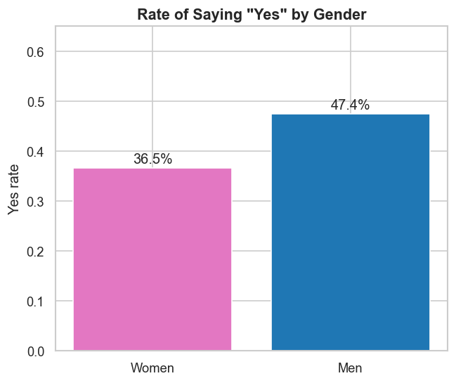

```python
gender_yes = df.groupby('gender')['dec'].mean().reset_index()
gender_yes['gender'] = gender_yes['gender'].map({0: 'Women', 1: 'Men'})

fig, ax = plt.subplots(figsize=(6, 5))
bars = ax.bar(gender_yes['gender'], gender_yes['dec'],
              color=['#e377c2', '#1f77b4'], edgecolor='white')
ax.set_title('Rate of Saying "Yes" by Gender', fontsize=13, fontweight='bold')
ax.set_ylabel('Yes rate')
ax.set_ylim(0, 0.65)
for bar, val in zip(bars, gender_yes['dec']):
    ax.text(bar.get_x() + bar.get_width()/2, bar.get_height() + 0.01,
            f'{val:.1%}', ha='center', fontsize=12)

plt.show()
```

Men are less selective than women. Men said "yes" in 47.4% of their dates compared to 36.5% for women - a consistent difference of nearly 11 percentage points. This suggests that women apply stricter criteria when deciding whether to pursue a connection.

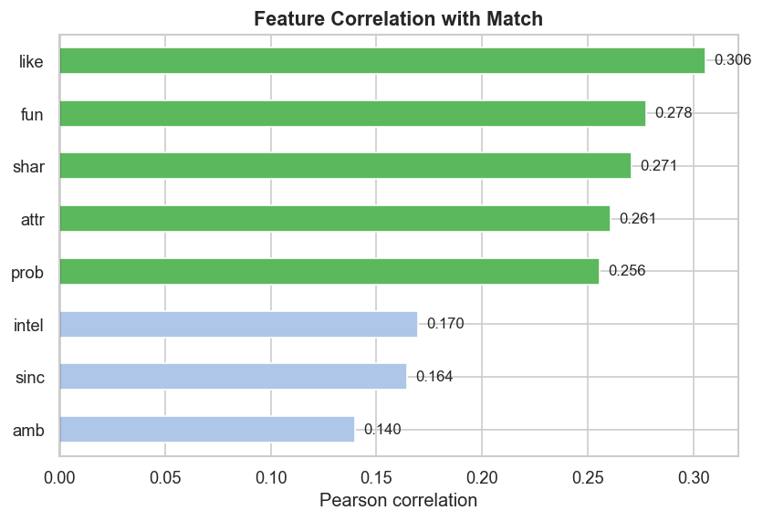

```python
rating_cols = ['attr', 'sinc', 'intel', 'fun', 'amb', 'shar', 'like', 'prob']
correlations = df[rating_cols + ['match']].corr()['match'].drop('match').sort_values()

fig, ax = plt.subplots(figsize=(8, 5))
colors = ['#5cb85c' if v >= 0.25 else '#aec7e8' for v in correlations.values]
correlations.plot(kind='barh', ax=ax, color=colors, edgecolor='white')
ax.set_title('Feature Correlation with Match', fontsize=13, fontweight='bold')
ax.set_xlabel('Pearson correlation')
ax.axvline(0, color='black', linewidth=0.8)
for i, val in enumerate(correlations.values):
    ax.text(val + 0.004, i, f'{val:.3f}', va='center', fontsize=10)

plt.show()
```

Fun, shared interests and overall liking drive matches the most. Among all post-date ratings, overall liking (like), fun, and shared interests show the strongest correlations with match outcomes. Sincerity, intelligence and ambition - while often declared as important - are much weaker predictors of actual mutual attraction.

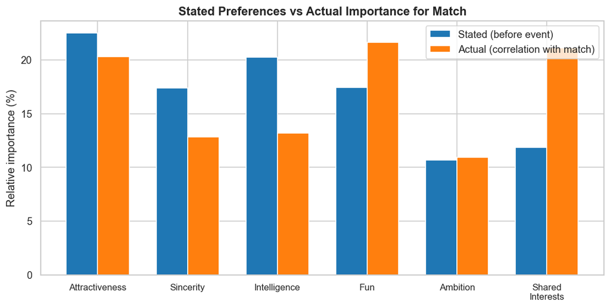

```python
pref_cols = ['attr1_1', 'sinc1_1', 'intel1_1', 'fun1_1', 'amb1_1', 'shar1_1']
labels = ['Attractiveness', 'Sincerity', 'Intelligence', 'Fun', 'Ambition', 'Shared\nInterests']

stated = df[pref_cols].mean().values
actual = [df[c].corr(df['match']) for c in ['attr', 'sinc', 'intel', 'fun', 'amb', 'shar']]
actual_norm = np.array(actual)
actual_norm = (actual_norm / actual_norm.sum()) * 100

x = np.arange(len(labels))
width = 0.35

fig, ax = plt.subplots(figsize=(11, 5))
ax.bar(x - width/2, stated, width, label='Stated (before event)', color='#1f77b4', edgecolor='white')
ax.bar(x + width/2, actual_norm, width, label='Actual (correlation with match)', color='#ff7f0e', edgecolor='white')
ax.set_xticks(x)
ax.set_xticklabels(labels, fontsize=10)
ax.set_ylabel('Relative importance (%)')
ax.set_title('Stated Preferences vs Actual Importance for Match', fontsize=13, fontweight='bold')
ax.legend()

plt.show()
```

**People are likely not to behave according to their stated preferences.** The preference variables collected before the event (what participants said they value in a partner) show near-zero correlations with actual match outcomes. Attractiveness was rated as the most important trait on average, yet it is not the strongest predictor of a match. This gap between stated and revealed preferences is one of the most interesting findings in the dataset.

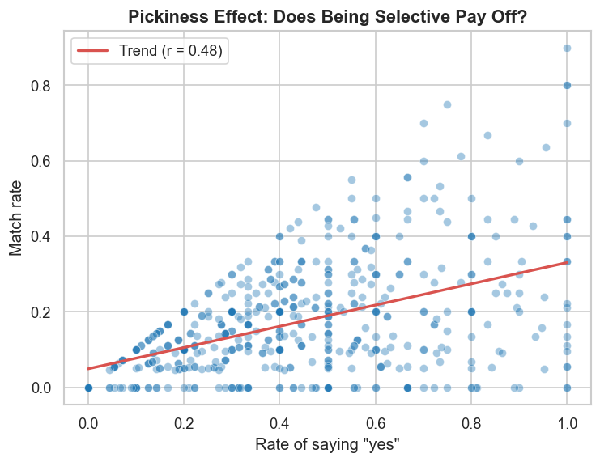

```python
person_stats = df.groupby('iid').agg(
    yes_rate=('dec', 'mean'),
    match_rate=('match', 'mean')
).reset_index()

fig, ax = plt.subplots(figsize=(7, 5))
ax.scatter(person_stats['yes_rate'], person_stats['match_rate'],
           alpha=0.4, color='#1f77b4', edgecolors='white', linewidth=0.5)
m, b = np.polyfit(person_stats['yes_rate'], person_stats['match_rate'], 1)
x_line = np.linspace(0, 1, 100)
ax.plot(x_line, m * x_line + b, color='#d9534f', linewidth=2,
        label=f'Trend (r = {person_stats["yes_rate"].corr(person_stats["match_rate"]):.2f})')
ax.set_xlabel('Rate of saying "yes"')
ax.set_ylabel('Match rate')
ax.set_title('Pickiness Effect: Does Being Selective Pay Off?', fontsize=13, fontweight='bold')
ax.legend()

plt.show()
```

**Being less selective is associated with more matches.** Participants who said "yes" more often had a higher match rate (correlation: 0.48). This is likely a mathematical effect - saying "yes" to more people simply increases the chances that at least some of them will say "yes" back.

## 6. Data Quality

### 6.1 Missing Data

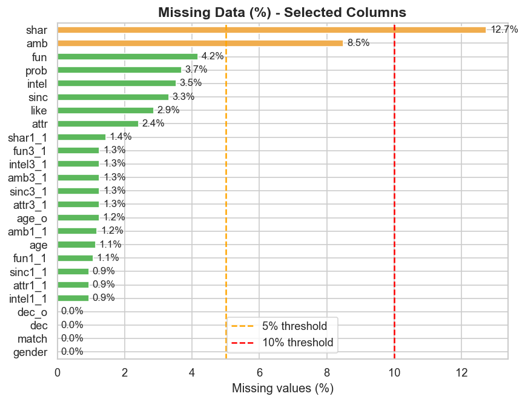

```python
missing = df[key_cols].isnull().mean() * 100
missing = missing.sort_values(ascending=True)

fig, ax = plt.subplots(figsize=(8, 6))
colors = ['#5cb85c' if v < 5 else '#f0ad4e' if v < 15 else '#d9534f' for v in missing.values]
missing.plot(kind='barh', ax=ax, color=colors, edgecolor='white')
ax.set_title('Missing Data (%) - Selected Columns', fontsize=14, fontweight='bold')
ax.set_xlabel('Missing values (%)')
ax.axvline(5, color='orange', linestyle='--', linewidth=1.5, label='5% threshold')
ax.axvline(10, color='red', linestyle='--', linewidth=1.5, label='10% threshold')
ax.legend()
for i, val in enumerate(missing.values):
    ax.text(val + 0.1, i, f'{val:.1f}%', va='center', fontsize=10)
plt.show()
```

The target variable `match` and all binary decision variables (`dec`, `dec_o`, `gender`) have **no missing values**, which is important for the classification goal. Most selected features have less than 5% missing data, which is generally considered acceptable.

The two most problematic columns are:

- **`shar`** (shared interests rating): **12.7% missing** (1,067 records) - the highest missingness among post-date ratings, likely because some waves skipped this question
- **`amb`** (ambition rating): **8.5% missing** (712 records) These two columns will require special attention during the modeling phase - either through imputation (e.g. median imputation) or by treating missingness as a feature in itself.

```python
missing_summary = df[key_cols].isnull().sum().reset_index()
missing_summary.columns = ['Column', 'Missing']
missing_summary['%'] = (missing_summary['Missing'] / len(df) * 100).round(1)
missing_summary = missing_summary.sort_values('%', ascending=False)
print(missing_summary.to_string(index=False))
```

```
  Column  Missing    %
    shar     1067 12.7
     amb      712  8.5
     fun      350  4.2
    prob      309  3.7
   intel      296  3.5
    sinc      277  3.3
    like      240  2.9
    attr      202  2.4
 shar1_1      121  1.4
  amb3_1      105  1.3
 sinc3_1      105  1.3
 attr3_1      105  1.3
  fun3_1      105  1.3
intel3_1      105  1.3
  amb1_1       99  1.2
   age_o      104  1.2
  fun1_1       89  1.1
     age       95  1.1
 sinc1_1       79  0.9
 attr1_1       79  0.9
intel1_1       79  0.9
     dec        0  0.0
   match        0  0.0
   dec_o        0  0.0
  gender        0  0.0
```

### 6.3 Outliers

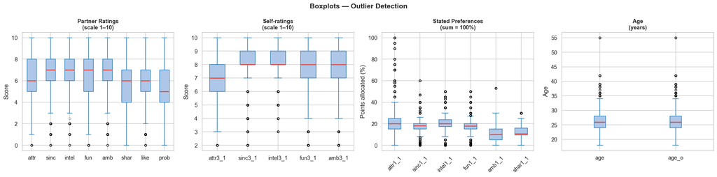

```python
rating_cols = ['attr', 'sinc', 'intel', 'fun', 'amb', 'shar', 'like', 'prob']
self_cols = ['attr3_1', 'sinc3_1', 'intel3_1', 'fun3_1', 'amb3_1']
pref_cols = ['attr1_1', 'sinc1_1', 'intel1_1', 'fun1_1', 'amb1_1', 'shar1_1']
age_cols = ['age', 'age_o']

boxplot_kwargs = dict(
    patch_artist=True,
    boxprops=dict(facecolor='#aec7e8', color='#1f77b4'),
    medianprops=dict(color='#d9534f', linewidth=2),
    whiskerprops=dict(color='#1f77b4'),
    capprops=dict(color='#1f77b4'),
    flierprops=dict(marker='o', color='#d9534f', alpha=0.3, markersize=4)
)

fig, axes = plt.subplots(1, 4, figsize=(20, 5))

df[rating_cols].boxplot(ax=axes[0], **boxplot_kwargs)
axes[0].set_title('Partner Ratings\n(scale 1-10)', fontsize=11, fontweight='bold')
axes[0].set_ylabel('Score')

df[self_cols].boxplot(ax=axes[1], **boxplot_kwargs)
axes[1].set_title('Self-ratings\n(scale 1-10)', fontsize=11, fontweight='bold')
axes[1].set_ylabel('Score')

df[pref_cols].boxplot(ax=axes[2], **boxplot_kwargs)
axes[2].set_title('Stated Preferences\n(sum = 100%)', fontsize=11, fontweight='bold')
axes[2].set_ylabel('Points allocated (%)')
axes[2].tick_params(axis='x', rotation=45)

df[age_cols].boxplot(ax=axes[3], **boxplot_kwargs)
axes[3].set_title('Age\n(years)', fontsize=11, fontweight='bold')
axes[3].set_ylabel('Age')

plt.suptitle('Boxplots - Outlier Detection', fontsize=14, fontweight='bold')
plt.tight_layout()
plt.savefig('plot_outliers_boxplot.png', bbox_inches='tight')
plt.show()
```

```python
outlier_results = []
for col in rating_cols + self_cols + pref_cols + age_cols:
    Q1 = df[col].quantile(0.25)
    Q3 = df[col].quantile(0.75)
    IQR = Q3 - Q1
    n_out = ((df[col] < Q1 - 1.5*IQR) | (df[col] > Q3 + 1.5*IQR)).sum()
    pct = n_out / df[col].notna().sum() * 100
    outlier_results.append((col, n_out, pct))

outlier_results.sort(key=lambda x: x[1], reverse=True)

print("\n=== Outliers (IQR method) ===")
print(f"{'Column':<12} {'Outliers':>10} {'%':>8}")
for col, n_out, pct in outlier_results:
    print(f"{col:<12} {n_out:>10} {pct:>7.1f}%")
```

```
=== Outliers (IQR method) ===
Column         Outliers        %
sinc1_1            1170    14.1%
sinc3_1             809     9.8%
fun1_1              734     8.9%
attr1_1             549     6.6%
intel1_1            506     6.1%
intel3_1            309     3.7%
amb3_1              247     3.0%
fun3_1              176     2.1%
age                 173     2.1%
age_o               173     2.1%
amb                 148     1.9%
sinc                122     1.5%
like                118     1.4%
shar1_1              86     1.0%
intel                53     0.7%
attr3_1              20     0.2%
fun                  14     0.2%
amb1_1               10     0.1%
attr                  8     0.1%
shar                  0     0.0%
prob                  0     0.0%
```

**Preference columns (attr1_1 etc.):** These show the highest spread and most outliers - `sinc1_1` has 14.1% and `fun1_1` has 8.9%. The boxplot clearly shows extreme values reaching up to 100 (someone allocating all points to a single trait). This reflects genuine differences in what people prioritize rather than data errors - some participants care overwhelmingly about one trait while others distribute points more evenly.

### 6.4 Values of Unknown Meaning

Among the selected columns used in this analysis, there are no values of unknown meaning. All attributes have clear, well-defined scales and interpretations - binary variables contain only 0 and 1, ratings are on a 1–10 scale, and preference columns represent percentage allocations summing to 100. The dataset does contain encoded columns such as `field_cd`, `career_c`, or `goal` which use integer codes without labels, but none of these are part of our analysis.

## 7. Revision of Validity of Goals for Further Data Mining

After completing the EDA, all six analytical goals defined in Section 2 remain valid and feasible.

**Classification of match** - fully supported; `match` is complete and key features like `like`, `fun`, and `attr` show meaningful correlations with match outcomes.

**Gender differences** - fully supported; both `gender` and `dec` are complete with no missing values, and a clear difference in yes rates was already observed.

**Feature importance analysis** - well-supported, with the exception of `shar` (12.7% missing) and `amb` (8.5% missing) which will require imputation before modeling.

**Stated vs. revealed preferences** - viable; the EDA already shows a clear gap between what participants say they value and what actually predicts a match.

**Self-assessment vs. outcomes** - valid but likely to yield weak results, as self-ratings show near-zero correlation with match; confirming this is itself a meaningful finding.

**Pickiness effect** - strongly supported; the EDA already shows a correlation of 0.48 between yes rate and match rate, making this the most clearly defined goal.